# Agriculture Production

### Producción Agrícola 2014

Para **México**, **Jalisco** y **San Martin Hidalgo**

```python
import pandas as pd

%matplotlib inline
```

```python
mex = pd.read_csv('2014_nacional.csv')
jal = pd.read_csv('2014_jalisco.csv')
smh = pd.read_csv('2014_smh.csv')
```

Las columnas de información son las siguientes:

```
1. Producto
2. Hectáreas sembradas
3. Hectáreas cosechadas
4. Producción en toneladas
5. Rendimiento en toneladas por hectárea
6. Valor de cada tonelada (en pesos)
7. Valor total (en pesos)
```

Ejemplo (producción **nacional**):

```python
mex.head()
```

|  | producto | sembrado_ha | cosechado_ha | produccion_ton | rendimiento_ton_ha | valor_ton | valor_produccion_mdp |
| --- | --- | --- | --- | --- | --- | --- | --- |
| 0 | ACEITUNA | 8560.95 | 3623.70 | 9994.42 | 2.76 | 7379.29 | 73751.72 |
| 1 | ACELGA | 746.25 | 741.75 | 8179.85 | 11.03 | 3027.41 | 24763.76 |
| 2 | ACHIOTE | 460.50 | 438.00 | 508.80 | 1.16 | 15708.15 | 7992.31 |
| 3 | AGAPANDO (Gruesa) | 97.00 | 96.00 | 50600.00 | 527.08 | 212.32 | 10743.39 |
| 4 | AGAVE | 120339.51 | 27689.34 | 2408884.28 | 87.00 | 4208.27 | 10137235.45 |

Primero veamos el riesgo de cada producto de cada base, lo calculamos como el ratio de las hectáreas sembradas y cosechadas y lo nombramos **exito**:

```python
mex['exito'] = mex.cosechado_ha/mex.sembrado_ha
jal['exito'] = jal.cosechado_ha/jal.sembrado_ha
smh['exito'] = smh.cosechado_ha/smh.sembrado_ha

mex[['producto', 'sembrado_ha', 'cosechado_ha', 'exito']].head()
```

|  | producto | sembrado_ha | cosechado_ha | exito |
| --- | --- | --- | --- | --- |
| 0 | ACEITUNA | 8560.95 | 3623.70 | 0.423282 |
| 1 | ACELGA | 746.25 | 741.75 | 0.993970 |
| 2 | ACHIOTE | 460.50 | 438.00 | 0.951140 |
| 3 | AGAPANDO (Gruesa) | 97.00 | 96.00 | 0.989691 |
| 4 | AGAVE | 120339.51 | 27689.34 | 0.230094 |

La columna **exito** es el valor de lo cosechado entre lo sembrado, es un valor entre 0 y 1, obviamente mide el exito de la siembra, o sea el porcentaje de lo que se logró cosechar. Entre más alto (cercano a 1) **más seguro** es el producto.

Los 15 productos más riesgosos en el territorio nacional son los siguientes:

```python
mex.sort_values('exito')[['producto', 'sembrado_ha', 'cosechado_ha', 'exito']].head(15)
```

|  | producto | sembrado_ha | cosechado_ha | exito |
| --- | --- | --- | --- | --- |
| 8 | ALAMO | 4.00 | 0.00 | 0.000000 |
| 174 | MAGUEY FORRAJERO | 231.00 | 0.00 | 0.000000 |
| 14 | ALGARROBO | 76.00 | 0.00 | 0.000000 |
| 39 | BAMBU | 425.00 | 0.00 | 0.000000 |
| 146 | HENEQUEN VERDE | 1775.00 | 0.00 | 0.000000 |
| 253 | RAMON | 71.50 | 0.00 | 0.000000 |
| 312 | ZAPOTE CHICLERO | 213.50 | 0.00 | 0.000000 |
| 222 | PALO DE ARCO | 11.00 | 0.00 | 0.000000 |
| 218 | PALMA DE ORNATO | 12.50 | 0.00 | 0.000000 |
| 175 | MAGUEY MIXIOTERO | 23.00 | 0.00 | 0.000000 |
| 112 | FLOR CERA | 38.00 | 0.00 | 0.000000 |
| 158 | JATROPHA | 1279.50 | 50.00 | 0.039078 |
| 219 | PALMA DE ORNATO (Planta) | 34.00 | 2.00 | 0.058824 |
| 4 | AGAVE | 120339.51 | 27689.34 | 0.230094 |
| 303 | VIVEROS (Planta) | 46.00 | 11.00 | 0.239130 |

El **agave** resulta ser bastante riesgoso, en la base de datos nacional, esta en el lugar 14! Solamente el **23%** de lo que se sembró en el 2014 fue cosechado.

Ha ha ha, alguien intentó sembrar bambú.

Antes de que se me pase quiero comparar los valores de éxito entre las tres bases para el agave:

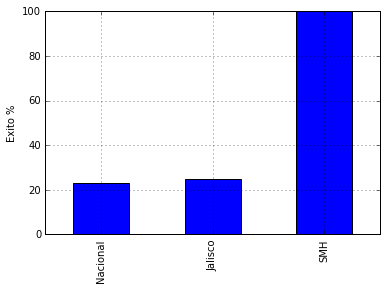

```python
m = pd.DataFrame(mex[mex['producto'] == 'AGAVE'])
j = pd.DataFrame(jal[jal['producto'] == 'AGAVE'])
s = pd.DataFrame(smh[smh['producto'] == 'AGAVE'])

f = [m, j, s]
e = pd.concat(f)
e.index = ['Nacional', 'Jalisco', 'SMH']
e.exito = e.exito*100
plt = e.exito.plot(kind='bar', grid=True)
plt.set_ylabel('Exito %')
```

Por alguna razón **San Martin** logra cosechar mucho más eficientemente, ya sea porque las tierras de San Martin son menos riesgosas, incluso óptimas para el agave, o posiblemente los valores de la tabla difieren de la realidad, pero eso no podremos saber, aun así la diferencia es bastante amplia.

Ya tenemos calculado el porcentaje de exito (o riesgo) para cada base, sería bueno analizar cuales son las mas rentables, la columna **rendimiento en toneladas por hectárea** nos indica cuantas toneladas salen por cada hectarea, ahora, un punto muy preocupante, las bases no pueden ser correctas para todas, pues es algo muy raro, resulta que para muchos productos de "hojas" (no se si así llamarlos), la producción en toneladas es DEMASIADO, debe haber un error en las unidades. Ignorando este punto preocupante, proseguimos:

Ordenamos los productos de **Jalisco** según las toneladas por hectarea y tenemos los diez productos que rinden más toneladas por hectárea:

```python
jal.sort_values('rendimiento_ton_ha', ascending=False).head(10)[['producto', 'produccion_ton', 'cosechado_ha', 'rendimiento_ton_ha']]
```

|  | producto | produccion_ton | cosechado_ha | rendimiento_ton_ha |
| --- | --- | --- | --- | --- |
| 53 | FRESA (Planta) | 51516000.00 | 318.00 | 162000.00 |
| 93 | PASTO (TAPETE) M2 | 6692700.00 | 677.00 | 9885.82 |
| 50 | FLORES (Manojo) | 193300.50 | 59.00 | 3276.28 |
| 101 | ROSA (Gruesa) | 19546.75 | 8.55 | 2286.17 |
| 49 | FLORES (Gruesa) | 37133.98 | 19.25 | 1929.04 |
| 9 | AVE DEL PARAISO (Gruesa) | 4050.00 | 13.50 | 300.00 |
| 81 | MARALFALFA | 14675.00 | 105.50 | 139.10 |
| 18 | CA�A DE AZUCAR SEMILLA | 156961.95 | 1550.50 | 101.23 |
| 16 | CA�A DE AZUCAR | 7541028.88 | 78804.70 | 95.69 |
| 2 | AGAVE | 1779310.74 | 18775.85 | 94.77 |

No puede ser, o sea que se produce **51,516,000** toneladas de fresa al año!?!? Y no no mas eso, sino que por cada hectárea le puedes sacar **162,000** toneladas (en promedio) !?!? Algo está mal no? Estos son números ridículos!

Bueno si acepatmos la veracidad de los datos, podemos proseguir y sacar otro dato, un cálculo del riesgo (columna de exito) según las toneladas producidas por hectárea, para ver cual es el producto más "voluminoso":

```python
mex['volumen'] = mex.exito*mex.rendimiento_ton_ha
jal['volumen'] = jal.exito*jal.rendimiento_ton_ha
smh['volumen'] = smh.exito*smh.rendimiento_ton_ha
```

Aquí están los 5 productos con el valor más alto según nuestro número "volumen" el cual es simplemente tomando en cuenta el riesgo cuantas toneladas salen por cada hectárea, para las tres bases, Nacional, Jalisco y SMH respectivamente. De nuevo checa los valores raros...

```python
mex[['producto', 'exito', 'rendimiento_ton_ha', 'volumen']].sort_values('volumen', ascending=False).head(5)
```

|  | producto | exito | rendimiento_ton_ha | volumen |
| --- | --- | --- | --- | --- |
| 244 | PLANTERO DE TABACO (Planta) | 1.0 | 4396588.76 | 4396588.76 |
| 152 | HORTENSIA (Planta) | 1.0 | 334840.00 | 334840.00 |
| 19 | ALMACIGO (Planta) | 1.0 | 304209.31 | 304209.31 |
| 42 | BELEN (Planta) | 1.0 | 257030.35 | 257030.35 |
| 121 | FRESA (Planta) | 1.0 | 251006.19 | 251006.19 |

```python
jal[['producto', 'exito', 'rendimiento_ton_ha', 'volumen']].sort_values('volumen', ascending=False).head(5)
```

|  | producto | exito | rendimiento_ton_ha | volumen |
| --- | --- | --- | --- | --- |
| 53 | FRESA (Planta) | 1.000000 | 162000.00 | 162000.00000 |
| 93 | PASTO (TAPETE) M2 | 0.994126 | 9885.82 | 9827.75351 |
| 50 | FLORES (Manojo) | 1.000000 | 3276.28 | 3276.28000 |
| 101 | ROSA (Gruesa) | 1.000000 | 2286.17 | 2286.17000 |
| 49 | FLORES (Gruesa) | 1.000000 | 1929.04 | 1929.04000 |

```python
smh[['producto', 'exito', 'rendimiento_ton_ha', 'volumen']].sort_values('volumen', ascending=False).head(5)
```

|  | producto | exito | rendimiento_ton_ha | volumen |
| --- | --- | --- | --- | --- |
| 21 | TOMATE ROJO (JITOMATE) | 1.0 | 116.5 | 116.5 |
| 3 | CA�A DE AZUCAR | 1.0 | 97.0 | 97.0 |
| 4 | CA�A DE AZUCAR SEMILLA | 1.0 | 96.0 | 96.0 |
| 0 | AGAVE | 1.0 | 91.5 | 91.5 |
| 18 | SANDIA | 1.0 | 35.0 | 35.0 |

Ahora todo eso es interesante si vas por una estrategia que involucra alto volumen en un area más reducida, lo cual si es interesante para algún agricultor pequeño (nosotros). Pero es necesario ahora analizar el rendimiento en dinero de cada producto.

Primero debemos ordenar la base segun el **valor de la tonelada** de cada producto para cada base. Enseguida podemos ver los 10 productos con la tonelada más valiosa para las tres bases (los valores son en pesos):

```python
mex.sort_values('valor_ton', ascending=False)[['producto', 'exito', 'produccion_ton', 'rendimiento_ton_ha', 'valor_ton']].head(10)
```

|  | producto | exito | produccion_ton | rendimiento_ton_ha | valor_ton |
| --- | --- | --- | --- | --- | --- |
| 91 | COLIFLOR SEMILLA | 1.000000 | 9.40 | 0.47 | 135509.00 |
| 162 | KENAF SEMILLA | 1.000000 | 22.50 | 0.45 | 104000.00 |
| 47 | BROCOLI SEMILLA | 1.000000 | 25.90 | 0.37 | 99060.00 |
| 300 | VAINILLA | 0.921105 | 419.56 | 0.45 | 86783.27 |
| 240 | PISTACHE | 0.551472 | 30.31 | 0.33 | 78449.36 |
| 72 | CEREZA | 1.000000 | 142.10 | 3.16 | 74665.73 |
| 281 | TARRAGON | 1.000000 | 78.75 | 7.88 | 72331.13 |
| 237 | PI�ON | 0.970620 | 1625.76 | 1.17 | 58215.78 |
| 45 | BLUEBERRY | 0.978297 | 18031.41 | 10.00 | 51966.57 |
| 213 | NUEZ | 0.697605 | 125758.45 | 1.67 | 49090.45 |

Mucho de que hablar aqui.

Primero al parecer las toneladas mas valiosas de méxico son las semillas de coliflor, brocoli y kenaf. Su probabilidad de éxito es del 100% según la base, y se puede notar que no se produce mucho de ninguna de esas semillas (semilla de coliflor solo 9 toneladas, de kenaf 22 y de brocoli casi 26). Los valores son interesantes porque por ejemplo la semilla de coliflor produce casi media tonelada por una sola hectárea, pero el valor de una tonelada es de más de \$130,000 pesos, o sea que le andas sacando \$65,000 pesos por hectarea.

También resaltan valores más obvios, como los de la cereza y el blueberry, curiosamente, aunque no se siembre mucho a comparación de otros productos, el porcentaje de éxito es bastante alto, 100% para la cereza y 98% para el blueberry, asi que en algunas partes del país, no es una inversión tan riesgosa, ademas de que se produce bastante por cada hectarea, por ejemplo se producieron 10 toneladas por cada hectarea y se cosecharon 1,800 hectareas de blueberry con un valor promedio de cada tonelada de \$52,000 pesos, o sea que hipoteticamente en el 2014 una hectarea bien sembrada de blueberry vale en promedio \$520,000 pesos!

Ahora, queda claro que requieren de mucha inversión inicial y de que probablemente se ocupa invernaderos.

Pasamos a analizar los resultados de Jalisco.

```python
jal.sort_values('valor_ton', ascending=False)[['producto', 'exito', 'produccion_ton', 'rendimiento_ton_ha', 'valor_ton']].head(10)
```

|  | producto | exito | produccion_ton | rendimiento_ton_ha | valor_ton |
| --- | --- | --- | --- | --- | --- |
| 35 | CHIA | 1.000000 | 9058.84 | 0.57 | 44408.06 |
| 66 | JAMAICA | 1.000000 | 9.46 | 0.59 | 43086.68 |
| 23 | CALABAZA (SEMILLA) O CHIHUA | 1.000000 | 698.70 | 1.44 | 42343.20 |
| 13 | BLUEBERRY | 1.000000 | 7834.07 | 9.38 | 32047.77 |
| 63 | HELECHO | 1.000000 | 1909.96 | 36.73 | 26300.00 |
| 89 | NUEZ | 0.941463 | 254.23 | 2.64 | 25809.74 |
| 5 | ALCACHOFA | 1.000000 | 244.50 | 16.30 | 20000.00 |
| 51 | FRAMBUESA | 1.000000 | 22261.34 | 14.46 | 16706.23 |
| 98 | PITAYA | 0.830565 | 1238.12 | 6.19 | 15665.67 |
| 83 | MEMBRILLO | 0.987179 | 1091.90 | 14.18 | 14829.49 |

Vuelve aparecer el blueberry! Aún más exitoso que el total nacional, pero algo muy intersante! => El blueberry en Jalisco vale **menos** que en el promedio nacional! En Jalisco, el promedio del valor de la tonelada de blueberry fue de \$32,000 pesos, mientras que el valor nacional fue de casi \$52,000, una diferencia del **38%**. ¿Por qué? Viendo el dato de la cantidad producida en toneladas, formé la hipótesis de que vale menos simplemente porque en Jalisco se produce mucho blueberry, la producción del 2014 nacional fue de alrededor de 18,000 toneladas mientras que solo en Jalisco se produjo casi 8,000 toneladas, por lo tanto técnicamente Jalisco aportó el 43% de la producción de México. Interesante ver como se refleja los efectos de la demanda y oferta aqui, pero pues es solo una hipotesis.

No muy sorprendentemente la chia fue muy valiosa en ese año, de hecho fue el producto de Jalisco más valioso, con un valor promedio por cada tonelada de \$44,400 pesos, dado que se produce aproximadamente media tonelada de chia, el valor de la hectarea de chia es de \$25,000 pesos. **Pregunta!** ¿Esto concuerda con tu experiencia?

Pasamos a San Martin:

```python
smh.sort_values('valor_ton', ascending=False)[['producto', 'exito', 'produccion_ton', 'rendimiento_ton_ha', 'valor_ton']].head(10)
```

|  | producto | exito | produccion_ton | rendimiento_ton_ha | valor_ton |
| --- | --- | --- | --- | --- | --- |
| 6 | CHIA | 1.000000 | 17.00 | 0.68 | 68394.70 |
| 9 | DURAZNO | 1.000000 | 78.40 | 8.00 | 17755.10 |
| 7 | CHILE VERDE | 1.000000 | 276.00 | 18.40 | 12300.00 |
| 10 | FRIJOL | 1.000000 | 23.76 | 1.32 | 10590.00 |
| 21 | TOMATE ROJO (JITOMATE) | 1.000000 | 2271.75 | 116.50 | 10194.50 |
| 8 | CIRUELA | 1.000000 | 5.00 | 5.00 | 10000.00 |
| 13 | LIMON | 0.907407 | 8290.80 | 18.80 | 5956.58 |
| 0 | AGAVE | 1.000000 | 121603.50 | 91.50 | 5781.06 |
| 1 | ARROZ PALAY | 1.000000 | 6020.55 | 7.65 | 5500.00 |
| 5 | CARTAMO | 1.000000 | 150.00 | 1.50 | 4395.00 |

Ya no apereció el blueberry :(. Pero sigue la chia en primer lugar, y de nuevo, suprise, el valor de la tonelada difiere del promedio Jalisciense, pero ahora, resulta que la chia vale **más** en San Martin, con un valor de \$68,394 por tonelada, o sea que se vende 54% más caro! Probablemente se deba a lo mismo de hace rato, solo que al reves, solo se producieron 17 toneladas en San Martin mientras que el total de Jalisco fue más de 9,000, o sea que solo representa el 0.18% de la producción Jalisciense, poca oferta a un producto bien demandado (en ese año claro) sube los precios.

¿En tu experiencia cual de estos 10 productos más valiosos de San Martin son los más riesgosos, independientemente de lo exitosos que fueron segun la base de datos?

Tomando en cuenta estos valores podemos pasar a otro análisis. Tomando el valor de la tonelada y el número de toneladas que salen de cada hectárea, calcularemos las hactareas más valiosas, a ver cuanto difiere el orden en comparación al ordenamiento anterior.

El valor se calcula simplemente multiplicando el valor de la tonelada por las toneladas por hectarea:

```python
mex['valor_ha'] = mex['rendimiento_ton_ha']*mex['valor_ton']
jal['valor_ha'] = jal['rendimiento_ton_ha']*jal['valor_ton']
smh['valor_ha'] = smh['rendimiento_ton_ha']*smh['valor_ton']
```

```python
mex.sort_values('valor_ha', ascending=False).head(10)[['producto', 'rendimiento_ton_ha', 'valor_ton', 'valor_ha']]
```

|  | producto | rendimiento_ton_ha | valor_ton | valor_ha |
| --- | --- | --- | --- | --- |
| 152 | HORTENSIA (Planta) | 334840.00 | 27.31 | 9.144480e+06 |
| 97 | CYCLAMEN (Planta) | 178813.10 | 22.97 | 4.107337e+06 |
| 297 | TULIPAN HOLANDES (Planta) | 145000.00 | 23.00 | 3.335000e+06 |
| 130 | GERBERA (Gruesa) | 10472.00 | 295.39 | 3.093324e+06 |
| 96 | CRISANTEMO (Planta) | 182788.46 | 11.87 | 2.169699e+06 |
| 306 | VIVEROS DE NUEZ | 19321.76 | 112.05 | 2.165003e+06 |
| 83 | CINERARIA (Planta) | 168069.44 | 11.99 | 2.015153e+06 |
| 207 | NOCHE BUENA (Planta) | 65558.63 | 30.44 | 1.995605e+06 |
| 129 | GERANIO (Planta) | 217293.13 | 9.09 | 1.975195e+06 |
| 59 | CALANCOE (Planta) | 182102.94 | 10.17 | 1.851987e+06 |

##### Error?

Mala suerte, regresa el problema anterior, al parecer las plantas de arriba producen muchisimas toneldas por hectárea, algo que no cuadra y estoy casi seguro de que es un error de las bases de datos, lo cual me hace cuestionar todo pero sin más información esto es lo que hay. Para olvidarnos de estas plantas, hice lo siguiente:

Aprovechando que la base datos terminaba el nombre de algunos productos con un "(Planta)" a los etiquetados como planta, simplemente los quité (temporalmente) (no todas las plantas desaparecieron pero al menos muchas si):

```python
no_plants = mex.sort_values('valor_ha', ascending=False)
no_plants = no_plants[
    (mex['producto'].str.endswith('(Planta)') != True)
    & (mex['producto'].str.endswith('(Gruesa)') != True)
    & (mex['producto'].str.endswith('(PLANTA)') != True)]
no_plants.head(10)[['producto', 'rendimiento_ton_ha', 'valor_ton', 'valor_ha']]
```

|  | producto | rendimiento_ton_ha | valor_ton | valor_ha |
| --- | --- | --- | --- | --- |
| 306 | VIVEROS DE NUEZ | 19321.76 | 112.05 | 2.165003e+06 |
| 150 | HONGOS Y SETAS | 65.84 | 21146.49 | 1.392285e+06 |
| 304 | VIVEROS DE DURAZNO | 50000.00 | 25.00 | 1.250000e+06 |
| 143 | HELECHO | 36.73 | 26300.00 | 9.659990e+05 |
| 119 | FRAMBUESA | 15.21 | 39371.73 | 5.988440e+05 |
| 281 | TARRAGON | 7.88 | 72331.13 | 5.699693e+05 |
| 43 | BERENJENA | 82.82 | 6838.72 | 5.663828e+05 |
| 120 | FRESA | 46.05 | 11923.30 | 5.490680e+05 |
| 45 | BLUEBERRY | 10.00 | 51966.57 | 5.196657e+05 |
| 267 | SOLIDAGO (Manojo) | 48290.91 | 9.20 | 4.442764e+05 |

La fresa y el blueberry vuelve aparecer, los dos son muy rentables, *como que ya salió la blueberry mucho no*? Será una señal? Utilizando un invernadero vertical no se que te parezca...

Volviendo a la realidad, pasamos a hacerlo mismo con las otras dos bases, para Jalisco y San Martin respectivamente:

```python
no_plants_jal = jal.sort_values('valor_ha', ascending=False)
no_plants_jal = no_plants_jal[
    (mex['producto'].str.endswith('(Planta)') != True)
    & (mex['producto'].str.endswith('(Gruesa)') != True)
    & (mex['producto'].str.endswith('(PLANTA)') != True)]

no_plants_smh = smh.sort_values('valor_ha', ascending=False)
no_plants_smh = no_plants_smh[
    (mex['producto'].str.endswith('(Planta)') != True)
    & (mex['producto'].str.endswith('(Gruesa)') != True)
    & (mex['producto'].str.endswith('(PLANTA)') != True)]
```

```python
no_plants_jal.head(10)[['producto', 'rendimiento_ton_ha', 'valor_ton', 'valor_ha']]
```

|  | producto | rendimiento_ton_ha | valor_ton | valor_ha |
| --- | --- | --- | --- | --- |
| 63 | HELECHO | 36.73 | 26300.00 | 965999.0000 |
| 49 | FLORES (Gruesa) | 1929.04 | 474.24 | 914827.9296 |
| 101 | ROSA (Gruesa) | 2286.17 | 281.22 | 642916.7274 |
| 109 | TOMATE ROJO (JITOMATE) | 70.18 | 8563.92 | 601015.9056 |
| 2 | AGAVE | 94.77 | 4881.32 | 462602.6964 |
| 52 | FRESA | 32.92 | 11258.32 | 370623.8944 |
| 5 | ALCACHOFA | 16.30 | 20000.00 | 326000.0000 |
| 13 | BLUEBERRY | 9.38 | 32047.77 | 300608.0826 |
| 51 | FRAMBUESA | 14.46 | 16706.23 | 241572.0858 |
| 92 | PAPAYA | 52.34 | 4569.18 | 239150.8812 |

Sorpresa o no? El **helecho** representa la hectárea más valiosa en Jalisco, y el valor se asemeja mucho al nacional. Por pura curiosidad veamos que porcentaje representa la producción de Jalisco de helecho con respecto del total nacional:

```python
nacional_helecho = mex[mex.producto == 'HELECHO']
jalisco_helecho = jal[jal.producto == 'HELECHO']

print "Producción Nacional: {}".format(nacional_helecho.produccion_ton.iloc[0])
print "Producción de Jalisco: {}".format(jalisco_helecho.produccion_ton.iloc[0])
```

```
Producción Nacional: 1909.96
Producción de Jalisco: 1909.96
```

Acaso hay un error? No lo hay, segun la base de datos, Jalisco produjo el **100%** de todo el helecho! Increible, si le atinó tu hermano.

En la lista de Jalisco, aperecen ya muchos productos conocidos, la fresa, el blueberry y la frambuesa, también van varias veces que sale el tomate, lo que no me esperaba era ver la papaya ha ha ha.

Ahora con San Martin:

```python
no_plants_smh.head(10)[['producto', 'exito', 'cosechado_ha', 'rendimiento_ton_ha', 'valor_ton', 'valor_ha']]
```

|  | producto | exito | cosechado_ha | rendimiento_ton_ha | valor_ton | valor_ha |
| --- | --- | --- | --- | --- | --- | --- |
| 21 | TOMATE ROJO (JITOMATE) | 1.000000 | 19.5 | 116.50 | 10194.50 | 1187659.250 |
| 0 | AGAVE | 1.000000 | 1329.0 | 91.50 | 5781.06 | 528966.990 |
| 7 | CHILE VERDE | 1.000000 | 15.0 | 18.40 | 12300.00 | 226320.000 |
| 9 | DURAZNO | 1.000000 | 9.8 | 8.00 | 17755.10 | 142040.800 |
| 13 | LIMON | 0.907407 | 441.0 | 18.80 | 5956.58 | 111983.704 |
| 18 | SANDIA | 1.000000 | 15.0 | 35.00 | 3051.41 | 106799.350 |
| 16 | MELON | 1.000000 | 35.0 | 28.00 | 3634.54 | 101767.120 |
| 8 | CIRUELA | 1.000000 | 1.0 | 5.00 | 10000.00 | 50000.000 |
| 6 | CHIA | 1.000000 | 25.0 | 0.68 | 68394.70 | 46508.396 |
| 1 | ARROZ PALAY | 1.000000 | 787.0 | 7.65 | 5500.00 | 42075.000 |

Interesante! El tomate es el producto que más valor le da a una hectárea, creo que habías dicho que era muy riesgoso pero pues en el 2014 lo que se sembró de tomate en San Martin, se cosechó. Ya viste cuanto vale la hectarea? **$1,187,659** de pesos! Se sembraron casi 20 hectareas, no son muchas, serán invernaderos? Tienes idea de quien siembra tomate?

El limon en el quinto lugar no es sorpresa, tampoco la sandia, y de nuevo aparece la chia.

¿Qué es el arroz palay? Me llama la atención.

Ya se vimos mucho, pero antes de acabar este analsis, quisiera saber cual de los productos de Jalisco y de San Martin producieron mucho valor pero a la vez se siembran menos de 5 hectareas:

```python
small_jal = jal[jal.cosechado_ha <= 5]
small_smh = smh[smh.cosechado_ha <= 5]
```

```python
small_jal.sort_values('valor_produccion_mdp', ascending=False)[['producto', 'cosechado_ha', 'valor_ha']]
```

|  | producto | cosechado_ha | valor_ha |
| --- | --- | --- | --- |
| 108 | TOMATE ROJO (JITOMATE SEMILLA) | 4.0 | 196000.0 |
| 64 | HORTALIZAS | 4.0 | 72000.0 |
| 27 | CAPULIN | 3.0 | 30000.0 |
| 79 | MANZANILLA | 1.5 | 45000.0 |
| 96 | PERA | 2.0 | 32340.0 |
| 86 | NONI | 2.0 | 15000.0 |
| 33 | CHABACANO | 1.0 | 21375.0 |
| 62 | HABA VERDE | 1.0 | 11200.0 |
| 105 | SOYA | 1.0 | 8625.0 |
| 72 | MAGUEY PULQUERO (MILES DE LTS.) | 0.0 | 0.0 |
| 90 | PALMA DE ORNATO (Planta) | 0.0 | 0.0 |
| 116 | UVA | 0.0 | 0.0 |

El tomate rojo es el número uno, las hortalizas el segundo, el capulin también. Son opciones cuando no tienes muchas hectareas, pero es necesario cuestionarnos, ¿ok valen mucho, y no se ocupan muchas hectáreas, pero no puede ser debido a que simplemente no hay demanda? No creo que la capulina sea tan demandada por ejemplo. El tomate si.

Ahora en San Martin:

```python
small_smh.sort_values('valor_produccion_mdp', ascending=False)[['producto', 'cosechado_ha', 'rendimiento_ton_ha', 'valor_ha']]
```

|  | producto | cosechado_ha | rendimiento_ton_ha | valor_ha |
| --- | --- | --- | --- | --- |
| 8 | CIRUELA | 1.0 | 5.0 | 50000.0 |
| 22 | TRIGO GRANO | 0.0 | 0.0 | 0.0 |

Esta vez no salió tan interesante, solamente un producto se sembró en cantidad de hectáreas menor a 5 en San Martin, la ciruela, y pues la verdad que el valor de la hectarea no esta tan mal! A ver, rapidamente lo comparamos con los promedios de Jalisco:

```python
jal[jal.producto == 'CIRUELA']
```

|  | producto | sembrado_ha | cosechado_ha | produccion_ton | rendimiento_ton_ha | valor_ton | valor_produccion_mdp | exito | volumen | valor_ha |
| --- | --- | --- | --- | --- | --- | --- | --- | --- | --- | --- |
| 39 | CIRUELA | 1317.5 | 1296.0 | 8677.63 | 6.7 | 8239.45 | 71498.9 | 0.983681 | 6.590664 | 55204.315 |

Quizas si hay más mercado! En el estado se cosecharon 1,296 hectáreas, y en San Martin solamente 1! Y el promedio de la hectarea es de $55,000, un poquito mejor que el de San Martin.

Bueno aqui termina este analisis preliminar.

Primeramente como te lo mencioné, espero que hayas analizado la información por tu propia cuenta mientras leias esto y mientras observabas las bases. ¿Que se te ocurre que podria ser una idea o hipotesis por analizar y comprobar? Solo piensa en una hipotesis o pregunta y podemos encontrar la respuesta en los datos. ¿Que piensas sobre los rendimientos de los productos en función de los espacios requeridos y su riesgo?

En mi opiníon hay mucha información interesante, pero para mi lo más interesante fué el hecho de encontrar diferentes valores de producción para los tres segmentos. ¿Tu a que crees que se deba esta diferencia (calidad, demanda/oferta, falta de información), y crees que hay algo interesante en esta "anomalía" (no se me ocurrió otra cosa, y no quise decir "rareza") de lo cual nos podriamos aprovechar, un posible arbitraje de precios?